# Support Vector Machine

#### What is Support Vector Machine?

The objective of the support vector machine algorithm is to find a hyperplane in an N-dimensional space(N — the number of features) that distinctly classifies the data points.

SVM constructs a hyperplane in multidimensional space to separate different classes. SVM generates optimal hyperplane, by minimizing an error.

##### SVM approach has some advantages compared to others classifiers. They are robust, accurate and very effective even in cases where the number of training samples is small.

## Hyperplane

A hyperplane is a decision plane which separates between a set of objects having different class memberships.

• in one dimension, a hyperplane is called a point

• in two dimensions, it is a line

[figure not shown]

### Support Vectors

Support vectors are the data points, which are closest to the hyperplane. These points will define the separating line better by calculating margins

[figure not shown]

## How do we find the Hyperplane ?

Here, we have three hyper-planes (A, B and C) and all are segregating the classes well. Now, How to identify the right hyper-plane?

[figure not shown]

Here, maximizing the distances between nearest data point (either class) and hyper-plane will help us to decide the right hyper-plane. This distance is called as

##### Margin.

[figure not shown]

#### Scenario

The SVM algorithm has a feature to ignore outliers and find the hyper-plane that has the maximum margin. Hence, we can say, SVM classification is robust to outliers.

[figure not shown]

###### some important parameters having higher impact on model performance, “kernel”, “gamma” and “C”.

## Kernel

SVM algorithms use a set of mathematical functions that are defined as the kernel. The function of kernel is to take data as input and transform it into the required form. ... These functions can be different types.

For example linear, nonlinear, polynomial, radial basis function (RBF), and sigmoid.

[figure not shown]

## C parameter

A high 'C' tries to minimize the misclassification of training data and a low value tries to maintain a smooth classification.

[figure not shown]

## Gamma parameter

To "raise" the points you use the RBF kernel, gamma controls the shape of the "peaks" where you raise the points. A small gamma gives you a pointed bump in the higher dimensions, a large gamma gives you a softer, broader bump.

Kernel coefficient for ‘rbf’, ‘poly’ and ‘sigmoid’. Higher the value of gamma, will try to exact fit the as per training data set i.e. generalization error and cause over-fitting problem.

Example: Let’s difference if we have gamma different gamma values like 0, 10 or 100.

[figure not shown]

### Advantages

SVMs work well on small as well as high dimensional data spaces.

It works effectively for high-dimensional datasets because of the fact that the complexity of the training dataset in SVM is generally characterized by the number of support vectors rather than the dimensionality.

SVMs can work effectively on smaller training datasets as they don’t rely on the entire data.

```python
import numpy as np
import pandas as pd
import matplotlib.pyplot as plt
%matplotlib inline
from sklearn.datasets import load_iris
iris = load_iris()
```

```python
iris.feature_names
```

```
['sepal length (cm)',
 'sepal width (cm)',
 'petal length (cm)',
 'petal width (cm)']
```

```python
iris.target_names
```

```
array(['setosa', 'versicolor', 'virginica'], dtype='<U10')
```

```python
df = pd.DataFrame(iris.data,columns=iris.feature_names)
df.head()
```

|  | sepal length (cm) | sepal width (cm) | petal length (cm) | petal width (cm) |
| --- | --- | --- | --- | --- |
| 0 | 5.1 | 3.5 | 1.4 | 0.2 |
| 1 | 4.9 | 3.0 | 1.4 | 0.2 |
| 2 | 4.7 | 3.2 | 1.3 | 0.2 |
| 3 | 4.6 | 3.1 | 1.5 | 0.2 |
| 4 | 5.0 | 3.6 | 1.4 | 0.2 |

```python
df.shape
```

```
(150, 4)
```

```python
df['target'] = iris.target
df.head()
```

|  | sepal length (cm) | sepal width (cm) | petal length (cm) | petal width (cm) | target |
| --- | --- | --- | --- | --- | --- |
| 0 | 5.1 | 3.5 | 1.4 | 0.2 | 0 |
| 1 | 4.9 | 3.0 | 1.4 | 0.2 | 0 |
| 2 | 4.7 | 3.2 | 1.3 | 0.2 | 0 |
| 3 | 4.6 | 3.1 | 1.5 | 0.2 | 0 |
| 4 | 5.0 | 3.6 | 1.4 | 0.2 | 0 |

```python
df['flower_name'] =df.target.apply(lambda x: iris.target_names[x])
df.head()
```

|  | sepal length (cm) | sepal width (cm) | petal length (cm) | petal width (cm) | target | flower_name |
| --- | --- | --- | --- | --- | --- | --- |
| 0 | 5.1 | 3.5 | 1.4 | 0.2 | 0 | setosa |
| 1 | 4.9 | 3.0 | 1.4 | 0.2 | 0 | setosa |
| 2 | 4.7 | 3.2 | 1.3 | 0.2 | 0 | setosa |
| 3 | 4.6 | 3.1 | 1.5 | 0.2 | 0 | setosa |
| 4 | 5.0 | 3.6 | 1.4 | 0.2 | 0 | setosa |

```python
df0 = df[df.target == 0]
df1 = df[df.target == 1]
df2 = df[df.target == 2]
```

### Sepal length vs Sepal Width (Setosa vs Versicolor)

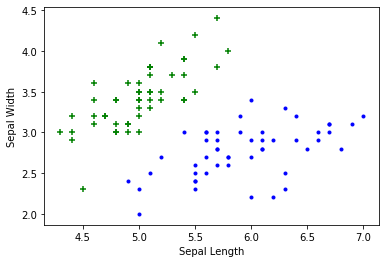

```python
plt.xlabel('Sepal Length')
plt.ylabel('Sepal Width')
plt.scatter(df0['sepal length (cm)'], df0['sepal width (cm)'],color="green",marker='+')
plt.scatter(df1['sepal length (cm)'], df1['sepal width (cm)'],color="blue",marker='.')
```

### Petal length vs Pepal Width (Setosa vs Versicolor)

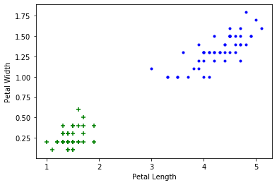

```python
plt.xlabel('Petal Length')
plt.ylabel('Petal Width')
plt.scatter(df0['petal length (cm)'], df0['petal width (cm)'],color="green",marker='+')
plt.scatter(df1['petal length (cm)'], df1['petal width (cm)'],color="blue",marker='.')
```

```python
from sklearn.model_selection import train_test_split
X = df.drop(['target','flower_name'], axis='columns')
y = df.target
```

```python
X.head()
```

|  | sepal length (cm) | sepal width (cm) | petal length (cm) | petal width (cm) |
| --- | --- | --- | --- | --- |
| 0 | 5.1 | 3.5 | 1.4 | 0.2 |
| 1 | 4.9 | 3.0 | 1.4 | 0.2 |
| 2 | 4.7 | 3.2 | 1.3 | 0.2 |
| 3 | 4.6 | 3.1 | 1.5 | 0.2 |
| 4 | 5.0 | 3.6 | 1.4 | 0.2 |

```python
y.head()
```

```
0    0
1    0
2    0
3    0
4    0
Name: target, dtype: int32
```

```python
X_train, X_test, y_train, y_test = train_test_split(X, y, test_size=0.2)
```

```python
len(X_train)
```

```
120
```

```python
len(X_test)
```

```
30
```

```python
from sklearn.svm import SVC
model = SVC(kernel = 'linear')

model.fit(X_train, y_train)
```

```
SVC(C=1.0, break_ties=False, cache_size=200, class_weight=None, coef0=0.0,
    decision_function_shape='ovr', degree=3, gamma='scale', kernel='linear',
    max_iter=-1, probability=False, random_state=None, shrinking=True,
    tol=0.001, verbose=False)
```

```python
model.score(X_test, y_test)
```

```
0.9666666666666667
```

```python
y_pred = model.predict(X_test)
print("Test pred :\n {}".format(y_pred))
```

```
Test pred :
 [1 0 1 1 1 2 1 2 1 0 2 1 2 1 0 2 1 0 2 2 1 0 2 2 0 2 1 2 0 2]
```

```python
y_test[:10]
```

```
98     1
48     0
133    2
99     1
94     1
121    2
55     1
138    2
59     1
19     0
Name: target, dtype: int32
```

```python
print("Test set score : {:.2f}".format(np.mean(y_pred==y_test)))
```

```
Test set score : 0.97
```

```python
model.predict([[4.8,3.0,1.5,0.3]])
```

```
array([0])
```